# Breast cancer survival analysis with R

Statistics M1

Raphaël Bonnet (PhD student C3M-U1065, Inserm, UCA)

08 octobre 2020

# Introduction notes

The curatedBreastData package contains 34 high-quality GEO gene expression microarray datasets, all with advanced breast cancer represented as S4 ExpressionObjects with attached clinical data (phenoData) for easier data analyses in R.

You will learn to explore this type of objects in R and to extract genetic and clinical feature.

We will overlook the Cox regression model for survival analysis and explore the relevance of most of the clinical covariates toward survival time.

# curatedBreastData package: Access & explore the data

These datasets all contain at least one survival and/or treatment response variable, and minimal treamtent information (such as whether they had chemotherapy or not.) Clinical variables were semantically normalized across all datasets to provide a powerful database for investigating genes that are related to clinical variables such as pathological complete response, ER and HER2 IHC pathology tests, pam50 subtyping tests (when available), and tumor stage. This database was original designed as a MySQL database, but has been re-represented as S4 ExpressionObjects for easier data analyses in R.

## Loading packages

```r
suppressMessages(library(Biobase))
suppressMessages(library(limma))
suppressMessages(library(survival))
suppressMessages(library(survminer))
suppressMessages(library(curatedBreastData))
suppressMessages(library(survivalROC))
suppressMessages(library(tibble))
suppressMessages(library(purrr))
suppressMessages(library(tidyr))
suppressMessages(library(dplyr))
suppressMessages(library(FactoMineR))
suppressMessages(library(GEOquery))
```

## Loading data

```r
#load up datasets that are in S4 expressionSet format.
#clinical data from master clinicalTable already linked to each sample
#in these ExpressionSets in the phenoData slot.

data(curatedBreastDataExprSetList)
data(clinicalData)
```

## First layer: the list of ExpressionSets

### using length(), head(), names() on list.eset

```r
#renaming for easier handling

list.eset=curatedBreastDataExprSetList
```

```r
# How big is loaded object
## your code here

# what's inside ?
## your code here
```

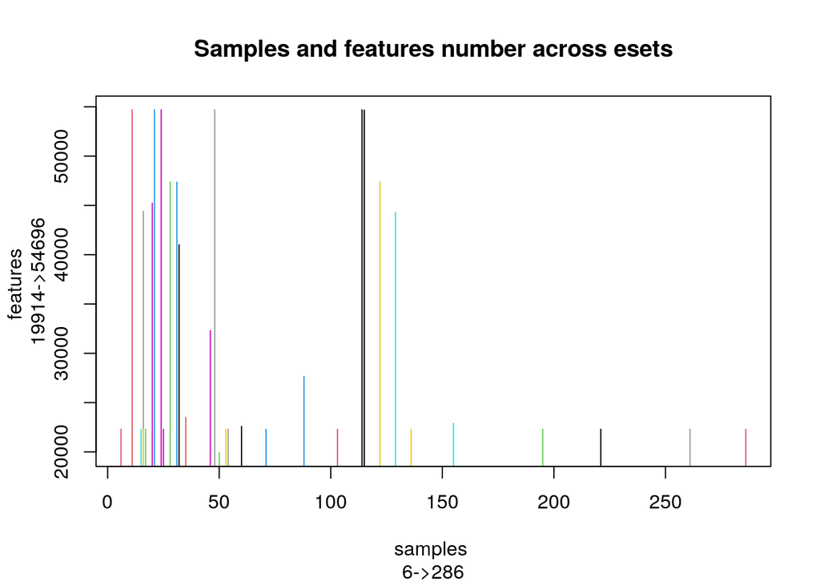

```r
#What are the dimensions of each eset (samples and genes)
dims=c()
for (l in seq_along(curatedBreastDataExprSetList))
{
  dims=rbind(dims,dim(curatedBreastDataExprSetList[[l]]))
}
plot(dims[,2],dims[,1],type = 'h',
     xlab = c('samples ', paste(range(dims[,2]),collapse = '->'),sep=''),
     ylab= c('features ',paste(range(dims[,1]),collapse = '->'),sep=''),
     col=c(1:34),
     main="Samples and features number across esets")
```

## Exploring the ExpressionSet

### -ExpressionSet Structure summary

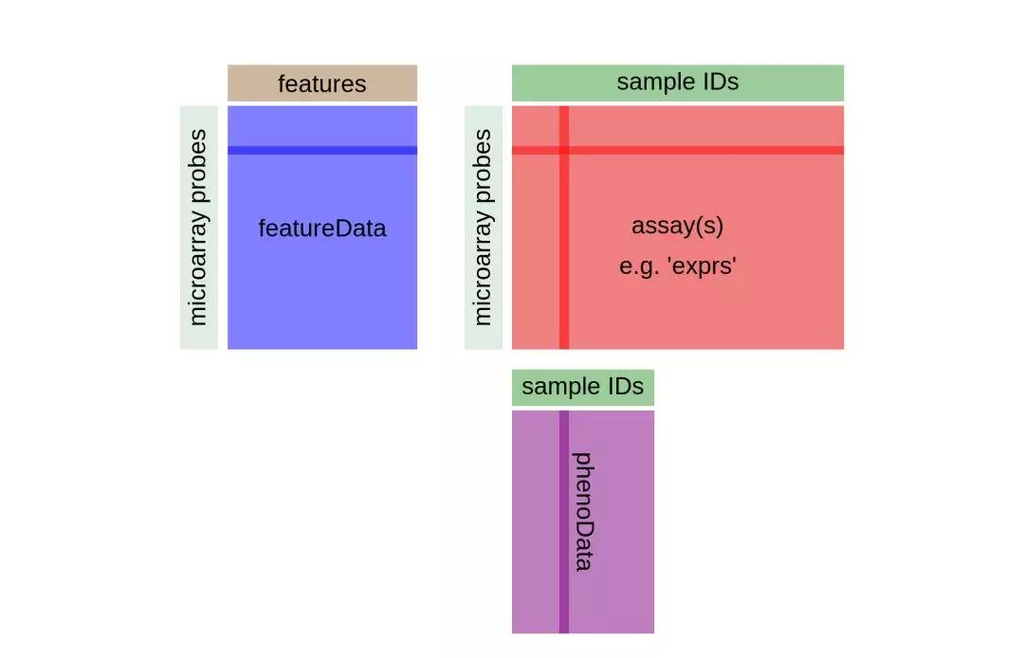

ExpressionSet is an object of type S4 that can be explored using the accessor "@" (S4 itself) and "$" (elements within S4)

## exprs()

### - Use class(), `eset@assayData$exprs` or exprs() to access gene expression data

```r
# lets look inside one object
eset=list.eset[[4]]
```

```r
#what types are eset and eset@assayData$exprs

#enter your code here

#have a look into exprs(eset)
#USE head()

#enter your code here
```

## fData()

### - Use `eset@featureData@data` or fData() to access features (gene) metadata

#### using class() head() levels() unique()

```r
#what types are fData(eset) and fData(eset)$gene_symbol


#look up the five first non duplicated gene names
```

* Use @ and $ accessors instead of fData() to obtain the same results

```r
#enter your code here
```

### - eset dimensions

```r
#what are the dimensions of eset
#enter your code here
```

## pData()

### - Use `eset@phenoData@data` or pData() to access samples pheno data

```r
# look inside pData(eset) for these dimentions [c(1:3), c(1:30)]
#enter your code here
```

### Here are some interesting features

```r
paste(names(pData(eset)),sapply(pData(eset), class),sep = " - ")[c(1:10,143:153)]
```

```
##  [1] "datasetName - factor"
##  [2] "dbUniquePatientID - numeric"
##  [3] "study_ID.x - integer"
##  [4] "patient_ID - integer"
##  [5] "GEO_GSMID - integer"
##  [6] "platform_ID - integer"
##  [7] "GEO_platform_ID - character"
##  [8] "AE_platform_ID - character"
##  [9] "coordinating_GSE_series_GSMID - integer"
## [10] "original_study_ID - character"
## [11] "radiotherapy - factor"
## [12] "chemotherapy - factor"
## [13] "hormone_therapy - factor"
## [14] "no_treatment - factor"
## [15] "methotrexate - factor"
## [16] "cetuximab - factor"
## [17] "carboplatin - factor"
## [18] "other - factor"
## [19] "taxaneGeneral - factor"
## [20] "neoadjuvant_or_adjuvant - factor"
## [21] "study_specific_protocol_number - factor"
```

Usually, only the 10~15 first info slots are availables upon data collection. It's very rare to have access to clinical data, here the clinical data has been collected by the package developpers.

### - Let's have a look at another unprocessed dataset.

```r
gse=GEOquery::getGEO('GSE39591')
```

* Use the class function on gse, gse$GSE39591_series_matrix.txt.gz

* Create a new variable for gse$GSE39591_series_matrix.txt.gz and check dims

* Use pData and fData to overlook the phenotypic and feature data.

```r
#enter your code here
```

## Overview of the gene expression: & heatmap & MDS plots

Back to breast cancer data. For the rest of the analysis we will focus on the 4th dataset in the eset list because there are some interesting clinical data associated to it.

```
##
## Analyzing dataset 1 or dataset named study_6577_GPL3883_all
```

[output not shown]

[output not shown]

[output not shown]

```
##
## Starting with  88patients.
```

```
## found no multiple samples from the same patient(s)
```

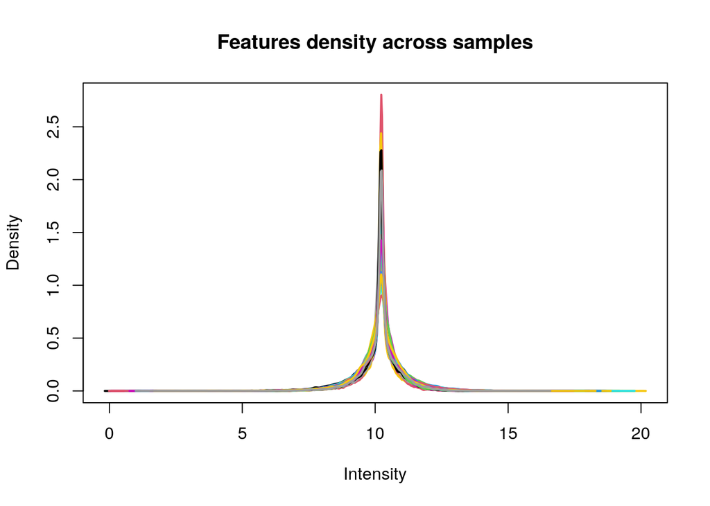

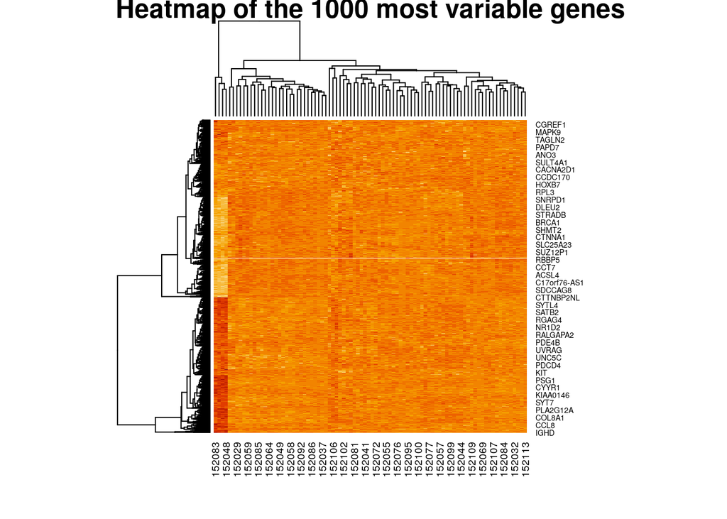

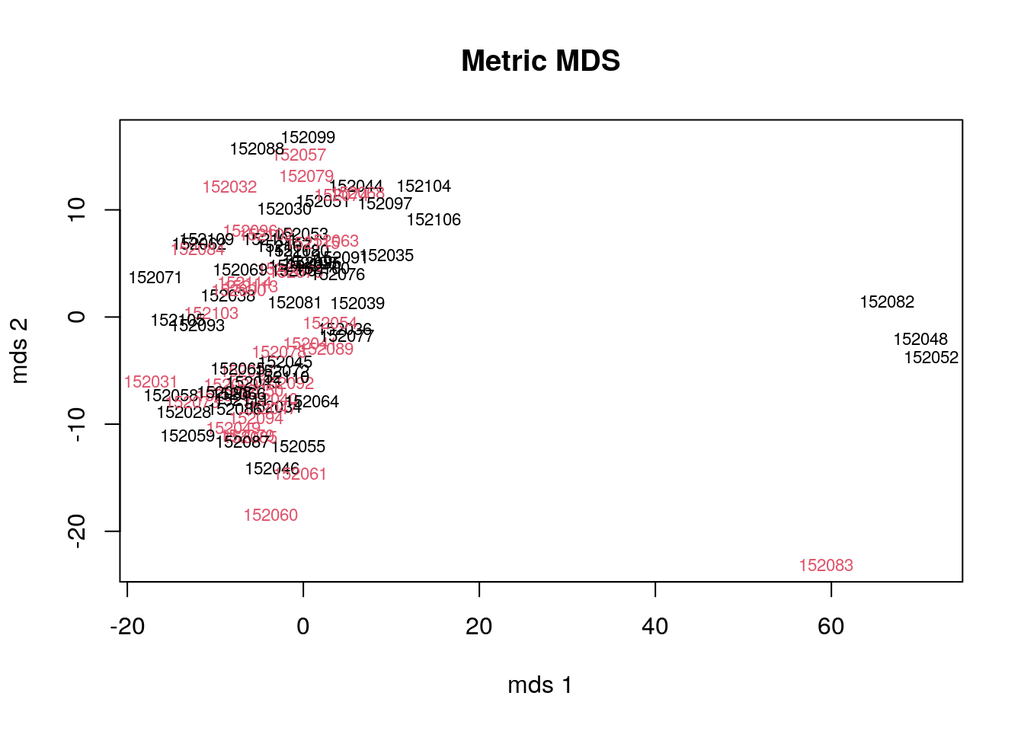

> Survival of the patient is overlayed in color (black: remission, red: relapse)

**These vizualisation gives us some insights on the quality of the expression set we are analysing.**

- We can have a look to the distribution of the feature (genes) expressions.
- We can overlook the expression of the top 1000 most variable genes in a heatmap to see wether or not some patterns already emerge.
- We can see here that the 1000 most variable genes fail to explain the survival of the patients.

## Sorting out the clinical table

```r
clinical=pData(eset)

clinical=data.frame(clinical$study_ID,
           clinical$OS,
           clinical$OS_months_or_MIN_months_of_OS,
           clinical$RFS,
           clinical$RFS_months_or_MIN_months_of_RFS,
           clinical$metastasis,
           clinical$age,
           clinical$ER_preTrt,
           clinical$ER_fmolmg_preTrt,
           clinical$tumor_size_cm_preTrt_preSurgery,
           clinical$tumor_stage_preTrt,
            clinical$preTrt_lymph_node_status,
           clinical$ERBB2_CPN_amplified,
           clinical$Erbeta_preTrt,
           clinical$PTEN_mutation,
           clinical$PTEN_pos
           )

paste(names(clinical),sapply(clinical, class),sep = " - ")
```

```
##  [1] "clinical.study_ID - integer"
##  [2] "clinical.OS - integer"
##  [3] "clinical.OS_months_or_MIN_months_of_OS - numeric"
##  [4] "clinical.RFS - integer"
##  [5] "clinical.RFS_months_or_MIN_months_of_RFS - numeric"
##  [6] "clinical.metastasis - integer"
##  [7] "clinical.age - numeric"
##  [8] "clinical.ER_preTrt - integer"
##  [9] "clinical.ER_fmolmg_preTrt - integer"
## [10] "clinical.tumor_size_cm_preTrt_preSurgery - numeric"
## [11] "clinical.tumor_stage_preTrt - character"
## [12] "clinical.preTrt_lymph_node_status - character"
## [13] "clinical.ERBB2_CPN_amplified - integer"
## [14] "clinical.Erbeta_preTrt - integer"
## [15] "clinical.PTEN_mutation - integer"
## [16] "clinical.PTEN_pos - integer"
```

* Use the head() function to display the content of the variable named "clinical"

```r
#enter your code here
```

## Gene expression impact on survival

HER2-positive breast cancer (Lancet, 2016)

Anti-HER2 treatment for HER2-positive breast cancer has changed the natural biology of this disease. This Series article reviews the main achievements so far in the treatment of both metastatic and early HER2-positive breast cancer. The success of neoadjuvant therapy in HER2-positive early breast cancer is especially acknowledged, as pertuzumab has been approved on the basis of a higher proportion of patients achieving a pathological complete response with pertuzumab and trastuzumab than with trastuzumab alone in a neoadjuvant study. Event-free survival after the confirmatory adjuvant trial completed recruitment was numerically better with pertuzumab plus trastuzumab than with trastuzumab alone. With survival rates of almost 5 years in women with metastatic HER2-positive breast cancer and 75% of patients achieving a pathological complete response, new treatments in the past decade have clearly improved the prognosis of HER2-positive breast cancer. Despite these achievements, however, the persisting high toll of deaths resulting from HER2-positive breast cancer calls for continued, intensive clinical research of newer therapies and combinations.

[figure not shown]

## Reminder to implement the model in R

To fit a cox model to data, we use the following code:

**fit=survfit(Surv(os_time,os) ~ covariate)**

**survfit()** is the command to compute an estimate of the survival curve of the model using the necessary data

**Surv(os_time,os)** containing the time to censor (here os_time) and censor (here os), returns the vector c(time,time+,etc)

**os_time** is a numeric vector associated to every patients containing the time from diagnosis (t0) to event (death, relapse, cencoring)

**os** is a boolean resulting from the question 'does an event occured?'

**covariate** set to 1 for the whole cohort or corresponds to a clinical feature (e.g: treatment)

**fit_table=coxph(Surv(os_time,os) ~ covariate)**

**fit_table() is the function to fit the model and to access statistics**

**- Using the mean of gene expression of all patients as a cut-off, it is possible to discretize (0: low expression, 1: high expression) the gene expression to create two groups of patients.**

#### - ERBB2 - receptor tyrosine kinases

```r
g=which(fData(eset)$gene_symbol=="ERBB2IP")
subset=apply(exprs(eset)[g,],MARGIN = 2,FUN = max)
erbb2=ifelse(subset>mean(subset),1,0)

gene=erbb2

#fit0=

#fit=

#fit table=

# info=summary(fit_table)
# pval=info$sctest[3]
# coef=info$coefficients[1]
# HR=info$coefficients[2]
# ggsurvplot(list('risk'=fit,'null.model'=fit0),data=clinical,
#            pval = TRUE,palette =c("steelblue2", "coral2",'Grey'),legend.labs =
#                c("low expression\ngroup","high expression\ngroup","all patients"),linetype = c(1,1,2),censor.shape="x", censor.size = 3,
#            title = "\tSurvival model - ERBB2",xlab = "Time in Months",pval.method =   TRUE,
#            ggtheme = theme_bw(), ncensor.plot = F, combine = T,surv.scale=c("percent"), xlim = c(0, 145))
```

#### - PTEN - tumor suppressor

```r
#fit0=

#fit=

#fit table=

# info=summary(fit_table)
# pval=info$sctest[3]
# coef=info$coefficients[1]
# HR=info$coefficients[2]
# ggsurvplot(list('risk'=fit,'null.model'=fit0),data=clinical,
#            pval = TRUE,palette =c("steelblue2", "coral2",'Grey'),legend.labs =
#                c("low expression\ngroup","high expression\ngroup","all patients"),
#            linetype = c(1,1,2),censor.shape="x", censor.size = 3,
#            title = "\tSurvival model - PTEN",xlab = "Time in Months",pval.method =   TRUE,
#            ggtheme = theme_bw(), ncensor.plot = F, combine = T,surv.scale=c("percent"), xlim = c(0, 145))
```

**Be very carful when anylising expression data as many other confounding factors can be responsible for the heterogeneity from one cohort to another.**

Here is an example of cohort heterogeneity of survival scores across all genes

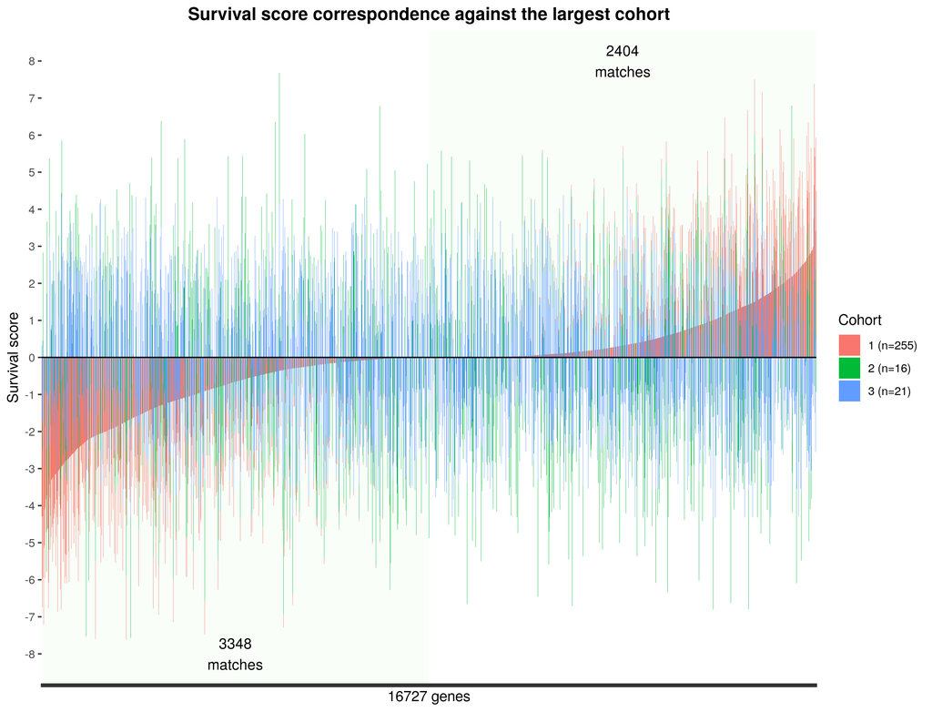

**Less than 35%** **((3348 + 2404)/ 16727) of genes have the same impact on survival in 3 independant cohorts.**

**In silico hypothesis must be confronted to a biological experiment**

## Relapse impact on survival

```r
#enter your code here

#fit=

#fit table=
```

```r
# info=summary(fit_table)
# pval=info$sctest[3]
# coef=info$coefficients[1]
# HR=info$coefficients[2]
# ggsurvplot(list('risk'=fit,'null.model'=fit0),data=clinical,
#            pval = TRUE,palette =c("coral2","steelblue2",'Grey'),legend.labs =
#                c("Relapse\ngroup","Relapse-free\ngroup","all patients"),linetype = c(1,1,2),censor.shape="x", censor.size = 3,
#            title = "\tSurvival model - Relapse free survival",xlab = "Time in Months",pval.method =   TRUE,
#            ggtheme = theme_bw(), ncensor.plot = F, combine = T,surv.scale=c("percent"), conf.int = TRUE, xlim = c(0, 145))
```

### How good is your model

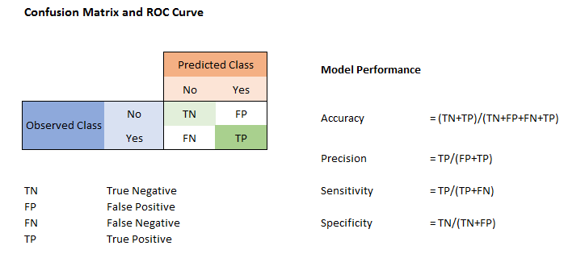

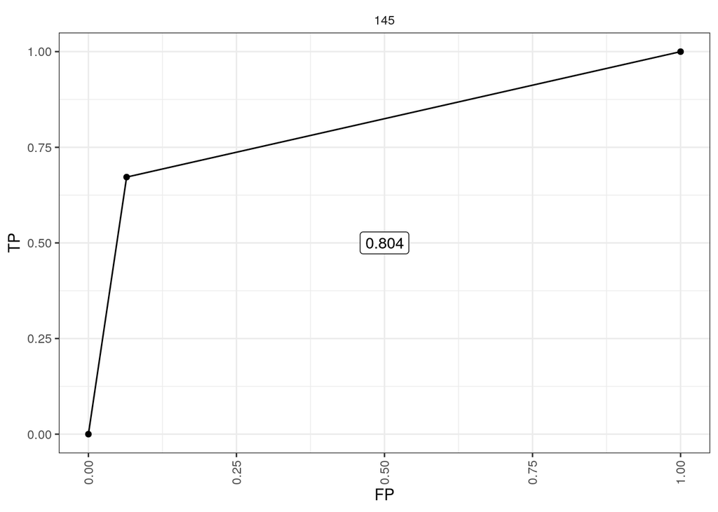

```r
fit_table=readRDS('fit_table.RDS')

#predict function
lp.pred <- predict(fit_table,
                  type="lp",
                  data=data.frame(clinical))


## Define a helper function to evaluate at various t
survivalROC_helper <- function(t) {
    survivalROC(Stime        = clinical$clinical.OS_months_or_MIN_months_of_OS,
                status       = clinical$clinical.OS,
                marker       = lp.pred,
                predict.time = t,
                method       = "NNE",
                span = 0.25 * nrow(clinical)^(-0.20))
}
## Evaluate at day 145

survivalROC_data <- tibble(t = 145) %>%
    mutate(survivalROC = map(t, survivalROC_helper),
           ## Extract scalar AUC
           auc = map_dbl(survivalROC, magrittr::extract2, "AUC"),
           ## Put cut off dependent values in a data_frame
           df_survivalROC = map(survivalROC, function(obj) {
               as_tibble(obj[c("cut.values","TP","FP")])
           })) %>%
    dplyr::select(-survivalROC) %>%
    unnest(cols = c(df_survivalROC)) %>%
    arrange(t, FP, TP)

## Plot
survivalROC_data %>%
    ggplot(mapping = aes(x = FP, y = TP)) +
    geom_point() +
    geom_line() +
    geom_label(data = survivalROC_data %>% dplyr::select(t,auc) %>% unique,
               mapping = aes(label = sprintf("%.3f", auc)), x = 0.5, y = 0.5) +
    facet_wrap( ~ t) +
    theme_bw() +
    theme(axis.text.x = element_text(angle = 90, vjust = 0.5),
          legend.key = element_blank(),
          plot.title = element_text(hjust = 0.5),
          strip.background = element_blank())
```

A receiver operating characteristic curve, or ROC curve, is a graphical plot that illustrates the diagnostic ability of a **binary** classifier system as its discrimination threshold is varied. It represent the FPR (false positive rate) against the TPR (true positive rate)

## Metastasis impact on survival

## Age impact on survival

**- Complete the code to evaluate the age impact on survival**

**- Break the cohort into two groups (< and >=50 years old)**

**- What can you say about the results of the regression model ?**

```r
#fit=

#fit table=
```

```r
# info=summary(fit_table)
# pval=info$sctest[3]
# coef=info$coefficients[1]
# HR=info$coefficients[2]
# ggsurvplot(list('risk'=fit,'null.model'=fit0),data=clinical,
#          pval = TRUE,palette =c("steelblue2", "coral2",'Grey'),legend.labs =
#              c("<50 yrs old\ngroup","> 50 yrs old\ngroup","all patients"),
#         linetype = c(1,1,2),censor.shape="x", censor.size = 3,
#          title = "\tSurvival model - Age",xlab = "Time in Months",pval.method =   TRUE,
#          ggtheme = theme_bw(), ncensor.plot = F, combine = T,surv.scale=c("percent"),xlim = c(0, 145) )
```

## Tumor size impact on survival 'clinical.tumor_size_cm_preTrt_preSurgery'

```r
#enter your code here

#fit=

#fit table=
```

```r
# pval=info$sctest[3]
# coef=info$coefficients[1]
# HR=info$coefficients[2]*10
# if (pval<0.05){print(pval);print(HR)}
# ggsurvplot(list('risk'=fit,'null.model'=fit0),data=clinical,
#            pval = TRUE,palette =c("steelblue2", "coral2",'Grey'),legend.labs =
#                c("Smaller tumor\ngroup","Bigger tumor\ngroup","all patients"),
#           linetype = c(1,1,2),censor.shape="x", censor.size = 3,
#            title = "\tSurvival model - Tumor size (preTrt)",xlab = "Time in Months",pval.method =TRUE,
#            ggtheme = theme_bw(), ncensor.plot = F, combine = T,surv.scale=c("percent"), xlim = c(0, 145) )
#
#
```

## Mutations impact on survival

### - ERBB2 amplification

```r
#enter your code here

#fit=

#fit table=
```

```r
# pval=info$sctest[3]
# coef=info$coefficients[1]
# HR=info$coefficients[2]
# print(pval)
# if (pval<0.05){print(pval);print(HR)}
# ggsurvplot(list('risk'=fit,'null.model'=fit0),data=clinical,
#            pval = TRUE,palette =c("steelblue2", "coral2",'Grey'),legend.labs =
#                c("down group","up group","all patients"),linetype = c(1,1,2),censor.shape="x", censor.size = 3,
#            title = "\tSurvival model - ERBB2 amplification",xlab = "Time in Month",pval.method =   TRUE,
#            ggtheme = theme_bw(), ncensor.plot = F, combine = T,surv.scale=c("percent"), xlim = c(0, 145) )
```

## Survival across studies

```
## Call:
## coxph(formula = Surv(clinical$OS_months_or_MIN_months_of_OS,
##     clinical$OS) ~ clinical$study_ID)
##
##   n= 340, number of events= 245
##    (11 observations deleted due to missingness)
##
##                        coef exp(coef)  se(coef)     z Pr(>|z|)
## clinical$study_ID 8.290e-05 1.000e+00 1.117e-05 7.424 1.13e-13 ***
## ---
## Signif. codes:  0 '***' 0.001 '**' 0.01 '*' 0.05 '.' 0.1 ' ' 1
##
##                   exp(coef) exp(-coef) lower .95 upper .95
## clinical$study_ID         1     0.9999         1         1
##
## Concordance= 0.541  (se = 0.022 )
## Likelihood ratio test= 62.97  on 1 df,   p=2e-15
## Wald test            = 55.12  on 1 df,   p=1e-13
## Score (logrank) test = 59.27  on 1 df,   p=1e-14
```

```
##       pvalue
## 1.375211e-14
## [1] 10.00083
```

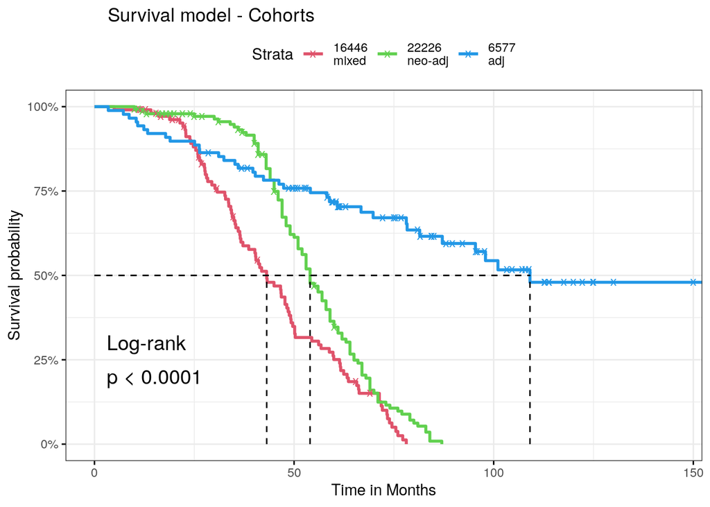

## Survival according to treatments

```
## Call:
## coxph(formula = Surv(clinical$OS_months_or_MIN_months_of_OS,
##     clinical$OS) ~ treatment_class)
##
##   n= 340, number of events= 245
##    (11 observations deleted due to missingness)
##
##                    coef exp(coef) se(coef)     z Pr(>|z|)
## treatment_class 0.27530   1.31693  0.04754 5.791 6.99e-09 ***
## ---
## Signif. codes:  0 '***' 0.001 '**' 0.01 '*' 0.05 '.' 0.1 ' ' 1
##
##                 exp(coef) exp(-coef) lower .95 upper .95
## treatment_class     1.317     0.7593       1.2     1.446
##
## Concordance= 0.549  (se = 0.023 )
## Likelihood ratio test= 33.91  on 1 df,   p=6e-09
## Wald test            = 33.54  on 1 df,   p=7e-09
## Score (logrank) test = 34.72  on 1 df,   p=4e-09
```

```
##       pvalue
## 3.806042e-09
## [1] 13.16928
```

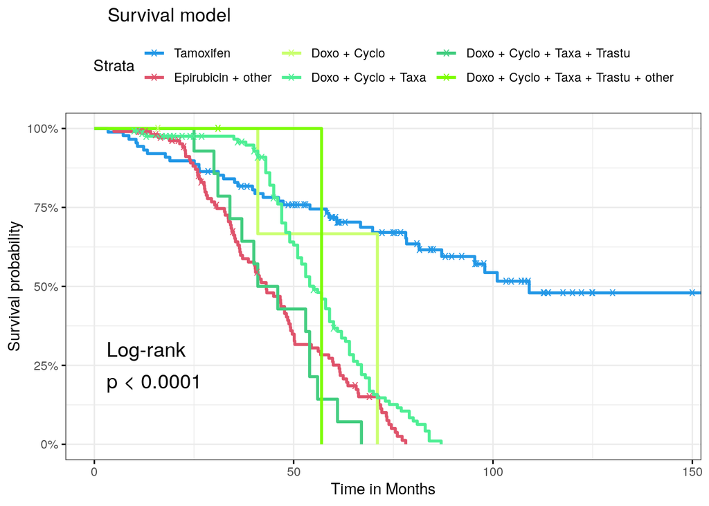

# Conclusion

- Clinical data are essential to perform a survival analysis and are often missing due to confidentiality.
- Gene expression often fail to robustly predict outcome when used alone without prior-knowledge or multiomics analysis.
- Cox reggression model is widely used and provide the user with a fast and comprehensive view of both:
  - Samples survival
  - Effect of covariates on survival

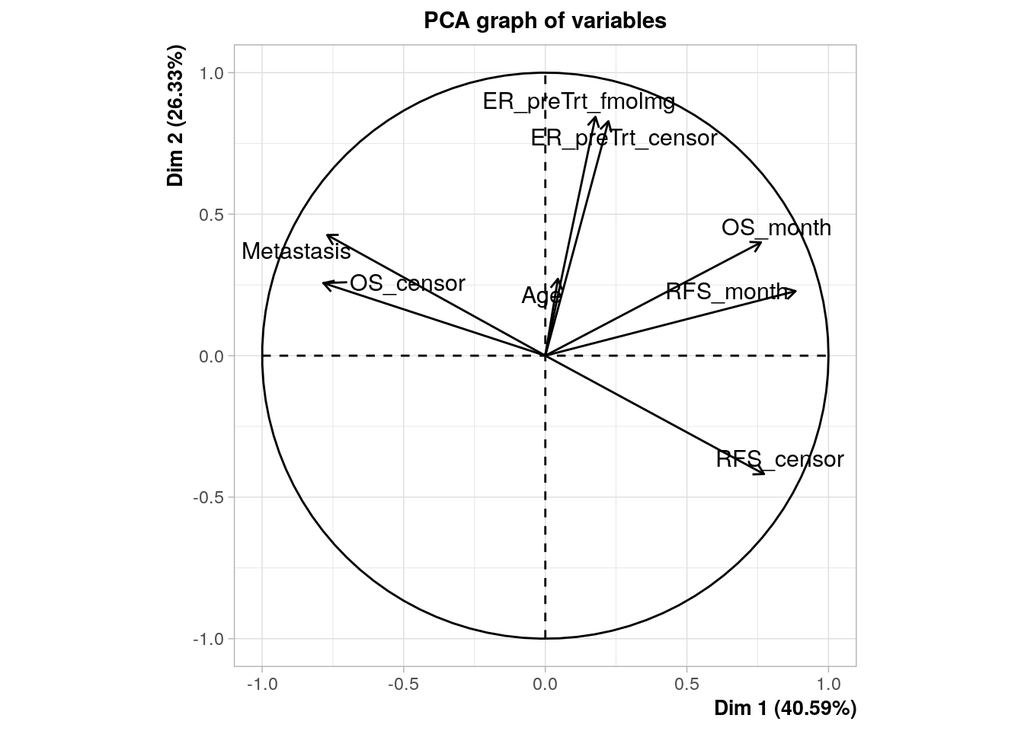

- Avoid hasty conclusion as pre-tretament covariates could be correlated with treatment.

(e.g. Pretreatment ER levels (fmol/mg) can influence the treatement protocol selection and thus the impact on survival of this ER levels is minimised by a more specific treatment)